# TidyTuesday 2020 week 16: Best Rap Artists

https://github.com/rfordatascience/tidytuesday/blob/master/data/2020/2020-04-14/readme.md

```r
pckgs <- c("tidyverse","lubridate", "here")

invisible(lapply(pckgs, library, character.only = TRUE))
```

```
## here() starts at C:/Users/Micha/Documents/Rko/data_visualization/TidyTuesdays/2020_04_14
```

Data Input:

```r
polls <- readr::read_csv('https://raw.githubusercontent.com/rfordatascience/tidytuesday/master/data/2020/2020-04-14/polls.csv')
rankings <- readr::read_csv('https://raw.githubusercontent.com/rfordatascience/tidytuesday/master/data/2020/2020-04-14/rankings.csv')
```

Lets look at the data:

```r
glimpse(rankings)
```

```
## Rows: 311
## Columns: 12
## $ ID     <dbl> 1, 2, 3, 4, 5, 6, 7, 8, 9, 10, 11, 12, 13, 14, 15, 16, 17, 1...
## $ title  <chr> "Juicy", "Fight The Power", "Shook Ones (Part II)", "The Mes...
## $ artist <chr> "The Notorious B.I.G.", "Public Enemy", "Mobb Deep", "Grandm...
## $ year   <dbl> 1994, 1989, 1995, 1982, 1992, 1993, 1993, 1992, 1994, 1995, ...
## $ gender <chr> "male", "male", "male", "male", "male", "male", "male", "mal...
## $ points <dbl> 140, 100, 94, 90, 84, 62, 50, 48, 46, 42, 38, 36, 36, 34, 32...
## $ n      <dbl> 18, 11, 13, 14, 14, 10, 7, 6, 7, 6, 5, 5, 4, 6, 5, 5, 4, 5, ...
## $ n1     <dbl> 9, 7, 4, 5, 2, 3, 2, 3, 1, 2, 2, 1, 2, 1, 1, 0, 2, 2, 1, 1, ...
## $ n2     <dbl> 3, 3, 5, 3, 4, 1, 2, 2, 3, 1, 0, 1, 2, 0, 1, 3, 1, 0, 1, 1, ...
## $ n3     <dbl> 3, 1, 1, 1, 2, 1, 2, 0, 1, 1, 3, 3, 0, 2, 2, 1, 0, 1, 1, 1, ...
## $ n4     <dbl> 1, 0, 1, 0, 4, 4, 0, 0, 1, 2, 0, 0, 0, 3, 0, 0, 1, 0, 1, 0, ...
## $ n5     <dbl> 2, 0, 2, 5, 2, 1, 1, 1, 1, 0, 0, 0, 0, 0, 1, 1, 0, 2, 1, 2, ...
```

Any missing values?

```r
rankings %>%
  map_lgl(~any(is.na(.))) %>%
  any()
```

```
## [1] FALSE
```

# Rankings

```r
summary(rankings)
```

```
##        ID           title              artist               year
##  Min.   :  1.0   Length:311         Length:311         Min.   :1979
##  1st Qu.: 78.5   Class :character   Class :character   1st Qu.:1994
##  Median :156.0   Mode  :character   Mode  :character   Median :1999
##  Mean   :156.0                                         Mean   :2000
##  3rd Qu.:233.5                                         3rd Qu.:2007
##  Max.   :311.0                                         Max.   :2019
##     gender              points             n               n1
##  Length:311         Min.   :  2.00   Min.   : 1.00   Min.   :0.0000
##  Class :character   1st Qu.:  4.00   1st Qu.: 1.00   1st Qu.:0.0000
##  Mode  :character   Median :  6.00   Median : 1.00   Median :0.0000
##                     Mean   : 10.32   Mean   : 1.72   Mean   :0.3441
##                     3rd Qu.: 10.00   3rd Qu.: 2.00   3rd Qu.:0.0000
##                     Max.   :140.00   Max.   :18.00   Max.   :9.0000
##        n2               n3               n4               n5
##  Min.   :0.0000   Min.   :0.0000   Min.   :0.0000   Min.   :0.0000
##  1st Qu.:0.0000   1st Qu.:0.0000   1st Qu.:0.0000   1st Qu.:0.0000
##  Median :0.0000   Median :0.0000   Median :0.0000   Median :0.0000
##  Mean   :0.3441   Mean   :0.3441   Mean   :0.3441   Mean   :0.3441
##  3rd Qu.:1.0000   3rd Qu.:1.0000   3rd Qu.:1.0000   3rd Qu.:1.0000
##  Max.   :5.0000   Max.   :3.0000   Max.   :4.0000   Max.   :5.0000
```

```r
rankings %>% n_distinct(title)
```

```
## [1] 311
```

311 songs - each ranked `n` times with the total amount of points equal to `points` .

```r
rankings <- rankings %>%
  mutate(decade = (year %/% 10)*10)
```

```r
rankings %>%
  count(decade)
```

| decade | n |
| --- | --- |
| 1970 | 1 |
| 1980 | 32 |
| 1990 | 138 |
| 2000 | 73 |
| 2010 | 67 |

Most of the songs come from the 90s, only one from the 70s, which one is it?

```r
rankings %>% filter(decade == 1970)
```

| ID | title | artist | year | gender | points | n | n1 | n2 | n3 | n4 | n5 | decade |
| --- | --- | --- | --- | --- | --- | --- | --- | --- | --- | --- | --- | --- |
| 13 | Rapper’s Delight | Sugarhill Gang | 1979 | male | 36 | 4 | 2 | 2 | 0 | 0 | 0 | 1970 |

What are the best years in terms of rating?

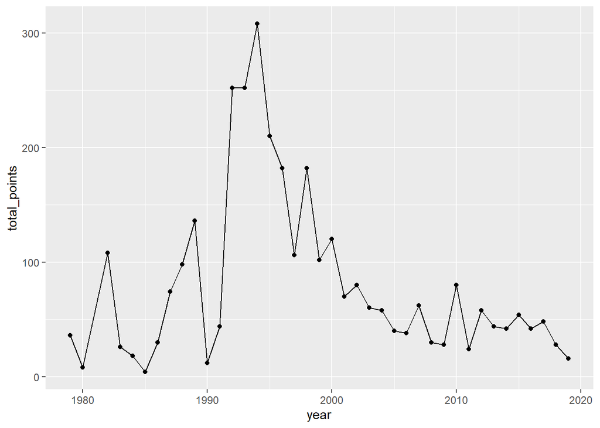

```r
rankings %>%
  group_by(year) %>%
  summarise(total_points = sum(points)) %>%
  ggplot(aes(x=year,y=total_points)) +
  geom_point() +
  geom_line()
```

The ratings spiked around the nineteen-nineties and have been on a decline since.

```r
rankings %>%
  group_by(decade) %>%
  summarise(max = max(points))
```

| decade | max |
| --- | --- |
| 1970 | 36 |
| 1980 | 100 |
| 1990 | 140 |
| 2000 | 32 |
| 2010 | 38 |

There is however a song in the last decade that surpassed the best rated one in the decade before.

```r
rankings %>%
  group_by(decade) %>%
  do(arrange(.,desc(points))) %>%
  slice(1)
```

| ID | title | artist | year | gender | points | n | n1 | n2 | n3 | n4 | n5 | decade |
| --- | --- | --- | --- | --- | --- | --- | --- | --- | --- | --- | --- | --- |
| 13 | Rapper’s Delight | Sugarhill Gang | 1979 | male | 36 | 4 | 2 | 2 | 0 | 0 | 0 | 1970 |
| 2 | Fight The Power | Public Enemy | 1989 | male | 100 | 11 | 7 | 3 | 1 | 0 | 0 | 1980 |
| 1 | Juicy | The Notorious B.I.G. | 1994 | male | 140 | 18 | 9 | 3 | 3 | 1 | 2 | 1990 |
| 17 | B.O.B. | OutKast | 2000 | male | 32 | 4 | 2 | 1 | 0 | 1 | 0 | 2000 |
| 11 | Runaway | Kanye West ft. Pusha T | 2010 | male | 38 | 5 | 2 | 0 | 3 | 0 | 0 | 2010 |

Runaway by Kanye West ft. Pusha T is rated higher than Rapper’s Delight and B.O.B.

Which artist has the most titles in the dataset?

```r
rankings %>%
  count(artist,sort = TRUE)
```

| artist | n |
| --- | --- |
| JAY-Z | 15 |
| Kendrick Lamar | 10 |
| A Tribe Called Quest | 7 |
| Eric B & Rakim | 7 |
| OutKast | 7 |
| 2Pac | 6 |
| Kanye West | 6 |
| Nas | 6 |
| Lil Wayne | 5 |
| Wu-Tang Clan | 5 |

[output cut: 197 more lines]

Jay-Z has the most rated titles - 15.

The majority of artists has only one title rated.

```r
rankings %>%
  count(artist) %>%
  count(n)
```

| n | nn |
| --- | --- |
| 1 | 172 |
| 2 | 15 |
| 3 | 5 |
| 4 | 5 |
| 5 | 2 |
| 6 | 3 |
| 7 | 3 |
| 10 | 1 |
| 15 | 1 |

```r
rankings %>%
  group_by(artist) %>%
  summarise(n_decades = n_distinct(decade)) %>%
  arrange(desc(n_decades))
```

| artist | n_decades |
| --- | --- |
| JAY-Z | 3 |
| Common | 2 |
| Eminem | 2 |
| Eric B & Rakim | 2 |
| Kanye West | 2 |
| Lil Wayne | 2 |
| Lupe Fiasco | 2 |
| Missy Elliott | 2 |
| Nas | 2 |
| OutKast | 2 |

[output cut: 197 more lines]

Jay-Z is also the only one who has a title rated within three decades period.

We know that The Notorious B.I.G. has the best rated title, does it also mean he has the most points in total?

```r
rankings %>%
  group_by(artist) %>%
  summarise(total_points = sum(points)) %>%
  arrange(desc(total_points)) %>%
  top_n(15)
```

| artist | total_points |
| --- | --- |
| The Notorious B.I.G. | 162 |
| Public Enemy | 144 |
| Wu-Tang Clan | 120 |
| JAY-Z | 102 |
| Mobb Deep | 98 |
| OutKast | 94 |
| Grandmaster Flash & The Furious Five | 90 |
| Nas | 90 |
| 2Pac | 88 |
| Dr Dre ft. Snoop Doggy Dogg | 86 |

[output cut: 6 more lines]

Yes! The Notorious B.I.G. has the most points in total as well as the best rated title.

```r
rankings %>%
  group_by(artist) %>%
  summarise(mean_points = mean(points), n = n()) %>%
  arrange(desc(mean_points)) %>%
  top_n(15)
```

[output not shown]

[output cut: 5 more lines]

Is there any title ranked in more then one year?

```r
rankings %>%
  count(title, sort = TRUE)
```

| title | n |
| --- | --- |
| All Of The Lights | 2 |
| Hip Hop | 2 |
| 1 Train | 1 |
| 22 Two’s | 1 |
| 4th Chamber | 1 |
| 93 ’Til Infinity | 1 |
| A Milli | 1 |
| Above The Clouds | 1 |
| Act Too (Love of My Life) | 1 |
| Aiiight Chill | 1 |

[output cut: 299 more lines]

There are two of them:

```r
rankings %>% filter(title %in% c('All Of The Lights','Hip Hop'))
```

| ID | title | artist | year | gender | points | n | n1 | n2 | n3 | n4 | n5 | decade |
| --- | --- | --- | --- | --- | --- | --- | --- | --- | --- | --- | --- | --- |
| 41 | Hip Hop | Dead Prez | 2000 | male | 16 | 2 | 1 | 0 | 1 | 0 | 0 | 2000 |
| 43 | All Of The Lights | Kanye West ft. Rihanna & Kid Cudi | 2010 | mixed | 16 | 2 | 0 | 2 | 0 | 0 | 0 | 2010 |
| 70 | All Of The Lights | Kanye West ft. Rihanna & Kid Cudi | 2010 | male | 10 | 1 | 1 | 0 | 0 | 0 | 0 | 2010 |
| 126 | Hip Hop | Mos Def | 1999 | male | 8 | 1 | 0 | 1 | 0 | 0 | 0 | 1990 |

So Hip Hop is a name shared by two distinct titles, however it looks the All Of The Lights has a male as well as mixed version, both from 2010.

```r
rankings %>%
  mutate(n_ratings = n1 + n2 + n3 + n4 + n5) %>%
  group_by()
```

| ID | title | artist | year | gender | points | n | n1 | n2 | n3 | n4 | n5 | decade | n_ratings |
| --- | --- | --- | --- | --- | --- | --- | --- | --- | --- | --- | --- | --- | --- |
| 1 | Juicy | The Notorious B.I.G. | 1994 | male | 140 | 18 | 9 | 3 | 3 | 1 | 2 | 1990 | 18 |
| 2 | Fight The Power | Public Enemy | 1989 | male | 100 | 11 | 7 | 3 | 1 | 0 | 0 | 1980 | 11 |
| 3 | Shook Ones (Part II) | Mobb Deep | 1995 | male | 94 | 13 | 4 | 5 | 1 | 1 | 2 | 1990 | 13 |
| 4 | The Message | Grandmaster Flash & The Furious Five | 1982 | male | 90 | 14 | 5 | 3 | 1 | 0 | 5 | 1980 | 14 |
| 5 | Nuthin’ But A ‘G’ Thang | Dr Dre ft. Snoop Doggy Dogg | 1992 | male | 84 | 14 | 2 | 4 | 2 | 4 | 2 | 1990 | 14 |
| 6 | C.R.E.A.M. | Wu-Tang Clan | 1993 | male | 62 | 10 | 3 | 1 | 1 | 4 | 1 | 1990 | 10 |
| 7 | 93 ’Til Infinity | Souls of Mischief | 1993 | male | 50 | 7 | 2 | 2 | 2 | 0 | 1 | 1990 | 7 |
| 8 | Passin’ Me By | The Pharcyde | 1992 | male | 48 | 6 | 3 | 2 | 0 | 0 | 1 | 1990 | 6 |
| 9 | N.Y. State Of Mind | Nas | 1994 | male | 46 | 7 | 1 | 3 | 1 | 1 | 1 | 1990 | 7 |
| 10 | Dear Mama | 2Pac | 1995 | male | 42 | 6 | 2 | 1 | 1 | 2 | 0 | 1990 | 6 |

[output cut: 301 more lines]

## Gender related questions

What is the ratio of men-women?

```r
rankings %>%
  count(gender)
```

| gender | n |
| --- | --- |
| female | 23 |
| male | 268 |
| mixed | 20 |

Whats the gender average rating?

```r
rankings %>%
  group_by(gender) %>%
  summarise(avg_rating = mean(points))
```

| gender | avg_rating |
| --- | --- |
| female | 8.347826 |
| male | 10.708955 |
| mixed | 7.400000 |

Are there years when female artists had the best rated title?

```r
rankings %>%
  group_by(year) %>%
  do(arrange(.,desc(points))) %>%
  slice(1) %>%
  filter(gender=="female")
```

| ID | title | artist | year | gender | points | n | n1 | n2 | n3 | n4 | n5 | decade |
| --- | --- | --- | --- | --- | --- | --- | --- | --- | --- | --- | --- | --- |
| 200 | Vicious Rap | Tanya ‘Sweet Tee’ Winley | 1980 | female | 6 | 1 | 0 | 0 | 1 | 0 | 0 | 1980 |
| 20 | Doo Wop (That Thing) | Lauryn Hill | 1998 | female | 28 | 5 | 1 | 1 | 1 | 0 | 2 | 1990 |
| 61 | Get Ur Freak On | Missy Elliott | 2001 | female | 10 | 3 | 0 | 0 | 1 | 0 | 2 | 2000 |
| 144 | Super Bass | Nicki Minaj | 2011 | female | 8 | 1 | 0 | 1 | 0 | 0 | 0 | 2010 |
| 64 | Bodak Yellow | Cardi B | 2017 | female | 10 | 2 | 0 | 0 | 1 | 1 | 0 | 2010 |

There are five years when female artists had the best rated title.

```r
rankings %>%
  filter(gender=="female") %>%
  arrange(desc(points))
```

| ID | title | artist | year | gender | points | n | n1 | n2 | n3 | n4 | n5 | decade |
| --- | --- | --- | --- | --- | --- | --- | --- | --- | --- | --- | --- | --- |
| 19 | U.N.I.T.Y. | Queen Latifah | 1993 | female | 30 | 5 | 1 | 1 | 1 | 1 | 1 | 1990 |
| 20 | Doo Wop (That Thing) | Lauryn Hill | 1998 | female | 28 | 5 | 1 | 1 | 1 | 0 | 2 | 1990 |
| 38 | Lost Ones | Lauryn Hill | 1998 | female | 16 | 3 | 0 | 1 | 1 | 0 | 1 | 1990 |
| 39 | Work It | Missy Elliott | 2002 | female | 16 | 3 | 0 | 0 | 2 | 1 | 0 | 2000 |
| 48 | The Rain (Supa Dupa Fly) | Missy Elliott | 1997 | female | 14 | 2 | 1 | 0 | 0 | 1 | 0 | 1990 |
| 61 | Get Ur Freak On | Missy Elliott | 2001 | female | 10 | 3 | 0 | 0 | 1 | 0 | 2 | 2000 |
| 64 | Bodak Yellow | Cardi B | 2017 | female | 10 | 2 | 0 | 0 | 1 | 1 | 0 | 2010 |
| 144 | Super Bass | Nicki Minaj | 2011 | female | 8 | 1 | 0 | 1 | 0 | 0 | 0 | 2010 |
| 182 | Mo(u)rning | Akua Naru | 2012 | female | 6 | 1 | 0 | 0 | 1 | 0 | 0 | 2010 |
| 186 | Paper Planes | M.I.A. | 2008 | female | 6 | 1 | 0 | 0 | 1 | 0 | 0 | 2000 |

[output cut: 13 more lines]

The best-rated female title however was not the best rated title in the year 1993.

What about a year when female artists would have the most points in total or the better average rating?

```r
rankings %>%
  group_by(gender, year) %>%
  summarise(sum_points = sum(points), avg_points = mean(points)) %>%
  ungroup() %>%
  group_by(year) %>%
  mutate(rank_sum = rank(desc(sum_points)),
         rank_avg = rank(desc(avg_points))) %>%
  filter(gender=="female" & (rank_sum==1|rank_avg==1))
```

| gender | year | sum_points | avg_points | rank_sum | rank_avg |
| --- | --- | --- | --- | --- | --- |
| female | 1980 | 6 | 6 | 1 | 1 |
| female | 1993 | 32 | 16 | 2 | 1 |
| female | 1997 | 18 | 9 | 3 | 1 |
| female | 1998 | 48 | 16 | 2 | 1 |
| female | 2001 | 14 | 7 | 2 | 1 |
| female | 2002 | 16 | 16 | 2 | 1 |
| female | 2011 | 10 | 5 | 2 | 1 |
| female | 2012 | 6 | 6 | 2 | 1 |

1980 is the only year when female artists had the most points in total. There are 8 years when female titles had higher avgerage rating then male or mixed artists.

Which female artist has : - the most titles - the most points - the best avg rating

```r
rankings %>%
  filter(gender=="female") %>%
  group_by(artist) %>%
  summarise(n_songs=n(), points_total=sum(points), points_avg=mean(points)) %>%
  arrange(desc(n_songs))
```

| artist | n_songs | points_total | points_avg |
| --- | --- | --- | --- |
| Missy Elliott | 4 | 42 | 10.5 |
| Lauryn Hill | 2 | 44 | 22.0 |
| Salt-N-Pepa | 2 | 8 | 4.0 |
| Akua Naru | 1 | 6 | 6.0 |
| Cardi B | 1 | 10 | 10.0 |
| Foxy Brown | 1 | 4 | 4.0 |
| Janelle Monae | 1 | 4 | 4.0 |
| Kanyi | 1 | 2 | 2.0 |
| Kreayshawn | 1 | 2 | 2.0 |
| Lauryn Hill ft. Mary J Blige | 1 | 4 | 4.0 |

[output cut: 8 more lines]

What is the first year a female title is rated?

```r
rankings %>%
  filter(gender=="female") %>%
  arrange(year) %>%
  top_n(10)
```

| ID | title | artist | year | gender | points | n | n1 | n2 | n3 | n4 | n5 | decade |
| --- | --- | --- | --- | --- | --- | --- | --- | --- | --- | --- | --- | --- |
| 61 | Get Ur Freak On | Missy Elliott | 2001 | female | 10 | 3 | 0 | 0 | 1 | 0 | 2 | 2000 |
| 238 | Oh Yeah | Foxy Brown | 2001 | female | 4 | 1 | 0 | 0 | 0 | 1 | 0 | 2000 |
| 39 | Work It | Missy Elliott | 2002 | female | 16 | 3 | 0 | 0 | 2 | 1 | 0 | 2000 |
| 296 | Pass That Dutch | Missy Elliott | 2003 | female | 2 | 1 | 0 | 0 | 0 | 0 | 1 | 2000 |
| 186 | Paper Planes | M.I.A. | 2008 | female | 6 | 1 | 0 | 0 | 1 | 0 | 0 | 2000 |
| 144 | Super Bass | Nicki Minaj | 2011 | female | 8 | 1 | 0 | 1 | 0 | 0 | 0 | 2010 |
| 274 | Gucci Gucci | Kreayshawn | 2011 | female | 2 | 1 | 0 | 0 | 0 | 0 | 1 | 2010 |
| 182 | Mo(u)rning | Akua Naru | 2012 | female | 6 | 1 | 0 | 0 | 1 | 0 | 0 | 2010 |
| 64 | Bodak Yellow | Cardi B | 2017 | female | 10 | 2 | 0 | 0 | 1 | 1 | 0 | 2010 |
| 290 | Ngqangqa | Kanyi | 2017 | female | 2 | 1 | 0 | 0 | 0 | 0 | 1 | 2010 |

[output cut: 2 more lines]